# Infering spatial gene expression from melanoma pseudo bulk data (Visium)

Yang

2024-09-12

### Setup

```r
library(limma)
library(Seurat)
library(readr)
library(tidyverse)
library(magrittr)
library(pander)
library(SingleCellExperiment)
library(reshape2)
library(BayesSpace)
library(MuSiC)
library(ggplot2)
library(ggpubr)
library(Matrix.utils)

theme_set(theme_bw())
panderOptions("big.mark", ",")
panderOptions("table.split.table", Inf)
panderOptions("table.style", "rmarkdown")
if (interactive()) setwd(here::here("analysis"))
```

### Summary

To demonstrate that Visium ST data can serve as an ST reference for Palette, here we present a tutorial using Visium data as the ST reference to infer the spatial gene expression of melanoma tissue. We utilize the Visium data from two melanoma slices, using one as the ST reference and converting the other into a pseudo bulk for Palette inference. The inferred expression patterns will then be compared to the original expression of the Visium reference.

### Load data

```r
melanoma_st1 <- readRDS(here::here("test","melanoma_1_Visium.rds"))
melanoma_st2 <- readRDS(here::here("test","melanoma_2_Visium.rds"))
```

### Construct pseudo bulk data and select highly expressed genes

Aggregate expression of ST data to generate pseudo bulk. melanoma_st2 is convert to pseudo bulk, while the aggregated expression of ST data (melanoma_st1) is used for selecting highly expressed genes.

```r
# Convert both to pseudo bulk data
melanoma_st1_sce <- SingleCellExperiment(assays = list(counts = melanoma_st1@assays$RNA@counts),
                           colData = melanoma_st1@meta.data)
groups <- colData(melanoma_st1_sce)[, c("orig.ident")]
melanoma_st1_bulk <- aggregate.Matrix(t(counts(melanoma_st1_sce)),
                       groupings = groups, fun = "sum") %>%
  as.data.frame() %>% t() %>% set_colnames("melanoma_st1") %>%
  as.data.frame()


melanoma_st2_sce <- SingleCellExperiment(assays = list(counts = melanoma_st2@assays$RNA@counts),
                           colData = melanoma_st2@meta.data)
groups <- colData(melanoma_st2_sce)[, c("orig.ident")]
melanoma_st2_bulk <- aggregate.Matrix(t(counts(melanoma_st2_sce)),
                       groupings = groups, fun = "sum") %>%
  as.data.frame() %>% t() %>% set_colnames("melanoma_st2") %>%
  as.data.frame()


# Select highly expressed genes in ST data (melanoma_st1)
melanoma_st1_bulk_high_exp <- melanoma_st1_bulk %>%
  as.data.frame() %>%
  dplyr::filter(rownames(.) %in% rownames(melanoma_st2_bulk)) %>%
  dplyr::filter(.$melanoma_st1 > 30)

# Reorder genes of pseudo bulk data (melanoma_st2) based on the ST data (melanoma_st1)
melanoma_st2_bulk_reorder <- melanoma_st2_bulk[match(rownames(melanoma_st1_bulk_high_exp), rownames(melanoma_st2_bulk)),,drop = FALSE] %>%
  as.data.frame()

# Define the ratio of the pseudo bulk (melanoma_st2) and the aggregate ST (melanoma_st1) as gene filter
gene_filter <- (melanoma_st2_bulk_reorder/melanoma_st1_bulk_high_exp) %>%
  set_colnames("ratio") %>%
  .[is.finite(rowSums(.)),, drop = FALSE]
```

We use density plot to visualize the expression ratios of the pseudo bulk (melanoma_st2) and the aggregated ST (melanoma_st1). We take the top 2000 genes closest to the mean and median ratios for the following analyses. These genes, regarded as stable genes, are highly expressed in both pseudo bulk and ST data.

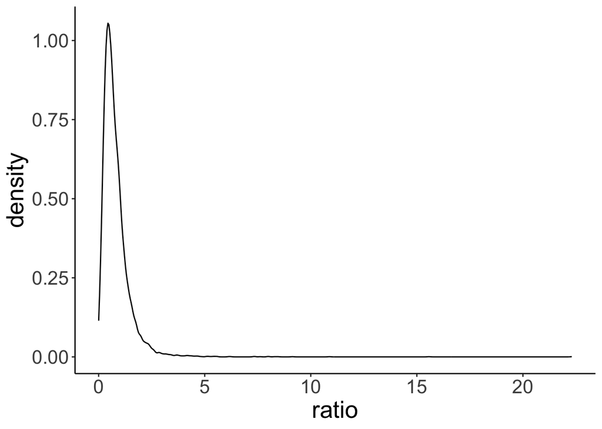

Density plot showing the expression ratio of pseudo bulk and aggregated ST data.

```r
ggplot(gene_filter, aes(x=ratio)) +
  geom_density() + theme_classic() +
  theme(text = element_text(size = 20))
```

```r
# The difference of gene ratio to the mean and median ratio
gene_filter$differ <- abs(gene_filter$ratio - (mean(gene_filter$ratio)+median(gene_filter$ratio))/2)

# Select the top 2000 genes closer to the mean and median for spatial clustering and deconvolution
high_exp_genes <- gene_filter %>%
  .[order(.$differ),] %>%
   top_n(.,-2000)
```

### Spatial clustering of ST data

BayesSpace is employed for spatial clustering on ST data (melanoma_st1). Only the selected 2000 highly-expressed, stable genes are used for spatial clustering. The cluster identities are then assigned to each ST spot.

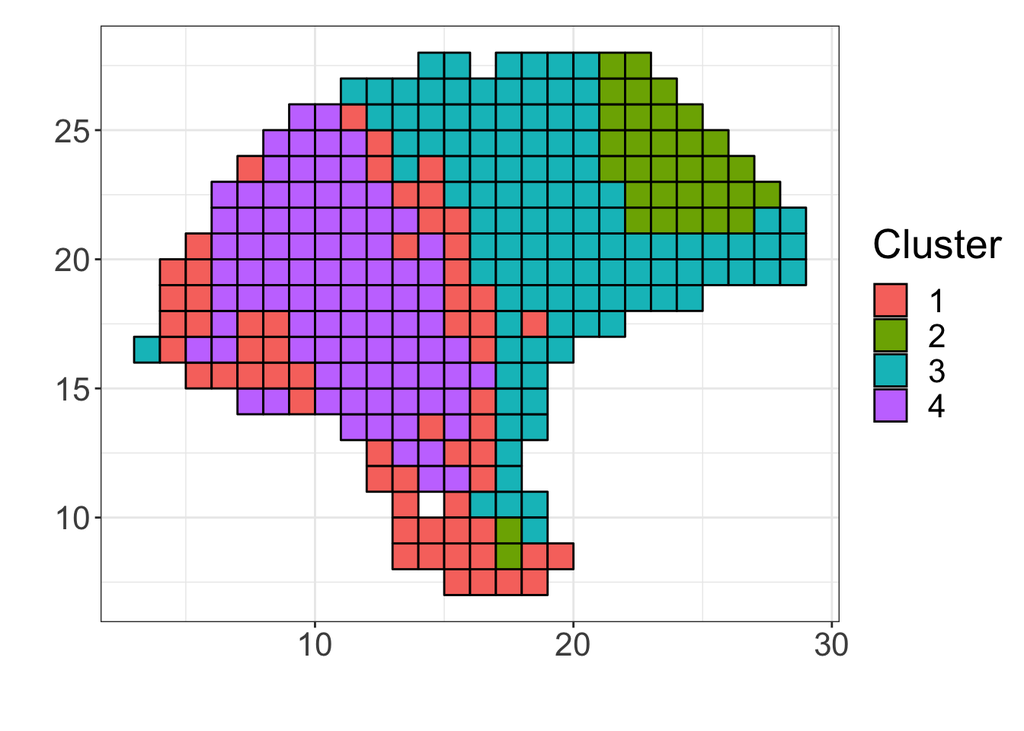

Spatial Clustering of ST data.

```r
# Set coordinates for BayesSpace
metadata <-  melanoma_st1@meta.data
metadata$col <-  metadata$Y %>% as.numeric()
metadata$row <-  metadata$X %>% as.numeric()

# Construct sce object
sce <- SingleCellExperiment(assays = list(counts = melanoma_st1@assays$RNA@counts, logcounts = melanoma_st1@assays$RNA@data),
                            colData=metadata)

# Only take highly-expressed, stable genes for spatial clustering
sce_filtered <- sce[rownames(high_exp_genes),]
sce_filtered <- spatialPreprocess(sce_filtered, platform="ST",
                              n.PCs=4,n.HVGs = 2000, log.normalize=TRUE)
# Select the number of clusters
p <- qTune(sce_filtered, qs=seq(2, 10), platform="ST", d=7)

# Clustering with BayesSpace
set.seed(149)
spatial_cluster <- spatialCluster(p, q=4, platform="ST", d=7,
                           init.method="kmeans", model="t", gamma=2,
                           nrep=10000, burn.in=100,
                           save.chain=TRUE)

# Visualizing spatial clusters
clusterPlot(spatial_cluster, color="black") +
  theme_bw() +
  xlab("") +
  ylab("") +
  theme(text = element_text(size = 20))
```

```r
melanoma_st1$spatial_cluster <- spatial_cluster$spatial.cluster
Idents(melanoma_st1) <- melanoma_st1$spatial_cluster

# Check the proportions of each cluster
prop_table <- prop.table(table(melanoma_st1$spatial_cluster)) %>% t()
colnames(prop_table) <- c("cluster 1","cluster 2","cluster 3","cluster 4")
rownames(prop_table) <- "Proportion"
knitr::kable(prop_table,
             caption = "The proportions of each cluster.")
```

The proportions of each cluster.

|  | cluster 1 | cluster 2 | cluster 3 | cluster 4 |
| --- | --- | --- | --- | --- |
| Proportion | 0.2081911 | 0.112628 | 0.3720137 | 0.3071672 |

### Pseudo bulk deconvolution

MuSiC is employed for deconvolution. Also, only the selected 2000 highly-expressed, stable genes are used for deconvolution. We can then achieve the abundances of each cluster in the pseudo bulk data.

```r
# Pre-process data for MuSiC
melanoma_st2_bulk$rep <- melanoma_st2_bulk$melanoma_st2
bulk.est <- Biobase::ExpressionSet(assayData = melanoma_st2_bulk %>% as.matrix())
sc.eset <- ExpressionSet(assayData = as.matrix(GetAssayData(melanoma_st1[rownames(high_exp_genes),])), phenoData = new("AnnotatedDataFrame", melanoma_st1@meta.data))

melanoma_st1$sample_id <- colnames(melanoma_st1)
sce <- SingleCellExperiment(assays = list(counts = melanoma_st1[rownames(high_exp_genes),]@assays$RNA@counts, logcounts = melanoma_st1[rownames(high_exp_genes),]@assays$RNA@data),
                            colData=melanoma_st1@meta.data)

# MuSiC deconvolution
Est.pro = music_prop(bulk.mtx = exprs(bulk.est), sc.sce = sce,  clusters = "spatial_cluster", samples = "sample_id")
proportion <- Est.pro$Est.prop.weighted
proportion_reorder <- proportion[, c("1","2","3","4")]

# The estimated proportion of each cluster in pseudo bulk data
prop_table_2 <- proportion_reorder[2,] %>% t()
colnames(prop_table_2) <- c("cluster 1","cluster 2","cluster 3","cluster 4")
rownames(prop_table_2) <- "Proportion"
knitr::kable(prop_table_2,
             caption = "The estimated proportions of each cluster in pseudo bulk data (melanoma_st2).")
```

The estimated proportions of each cluster in pseudo bulk data (melanoma_st2).

|  | cluster 1 | cluster 2 | cluster 3 | cluster 4 |
| --- | --- | --- | --- | --- |
| Proportion | 0.1910297 | 0.1346806 | 0.3857395 | 0.2885502 |

### Variable factor calculation

Here we define a variable factor to adjust the expression difference between the pseudo bulk data and the Visium ST reference. The variable factor is defined as the ratio of bulk expression matrix (melanoma_st2) to the pseudo bulk matrix, which is constructed by the cluster expression of Visium data (melanoma_st1) and cluster abundance of bulk (melanoma_st2). Each gene has its own variable factor to adjust its expression.

```r
# The average gene expression of each cluster
cluster.averages <- AverageExpression(melanoma_st1) %>%
  as.data.frame() %>%
  as.matrix()

cluster.averages_filtered <- cluster.averages %>%
  as.data.frame() %>%
  rownames_to_column() %>%
  dplyr::filter(.$rowname %in% rownames(melanoma_st2_bulk)) %>%
  column_to_rownames(var= "rowname")  %>%
  as.matrix() %>%
  .[,c("RNA.1","RNA.2","RNA.3","RNA.4")]

# The abundance of each cluster in the pseudo bulk (melanoma_st2)
abundance <- proportion_reorder %>%
  .[1,,drop=FALSE] %>%
  as.data.frame() %>%
  as.matrix()


melanoma_st2_bulk_reorder <- melanoma_st2_bulk[match(rownames(cluster.averages_filtered), rownames(melanoma_st2_bulk)),1,drop=FALSE] %>%
  as.data.frame()

# Define variable factor
variable_factor <- (melanoma_st2_bulk_reorder/(cluster.averages_filtered %*% (abundance %>% t()))) %>%
  .[is.finite(rowSums(.)),, drop = FALSE] %>%
  as.data.frame() %>%
  set_colnames("var")

variable_factor_matrix <- rep(variable_factor,4) %>%
  as.data.frame() %>%
  set_colnames(c("1","2","3","4"))
rownames(variable_factor_matrix) <- rownames(variable_factor)
```

```
## [1] "The top 5 rows of variable factor"
```

```
##                 var
## PSME2  1.604764e-02
## CUEDC1 1.494017e+02
## RPLP1  1.303056e-42
## TM9SF3 1.483871e+01
## DEF8   1.234879e+01
```

The adjusted matrix is the overall gene expression of each cluster, which is obtained by taking the dot product of the cluster expression matrix of Visium ST slice and the variable factor.

```r
adjusted_matrix <- ((cluster.averages_filtered[rownames(variable_factor_matrix),] * variable_factor_matrix))
colnames(adjusted_matrix) <- c("cluster 1","cluster 2","cluster 3","cluster 4")
```

```
## [1] "The top 5 rows of adjusted matrix"
```

```
##          cluster 1    cluster 2    cluster 3   cluster 4
## PSME2  2794.605496 1.555389e-01 3.727310e-01    83.11439
## CUEDC1   84.820230 2.333765e+01 2.053309e+01   151.56207
## RPLP1     1.560942 1.995685e-12 1.513229e-14 23360.58502
## TM9SF3   46.623255 2.990017e+01 1.302895e+01   104.10951
## DEF8     37.641853 7.048252e+01 5.487720e+01   101.01659
```

### Estimate expression of each spot

The expression of each spot is estimated through a loop algorithm. In each iteration of the loop, the procedure begins by selecting one random spot and its neighboring spots. The number of neighboring spots can be changed depending on the data. The expression of spots belonging to the same cluster is aggregated to form a pseudo bulk data called regional cluster ST (RST).

Here we assume that the ratio of RST to the entire ST data is equal to the ratio of the adjusted RST to the adjusted matrix. We define the ratio of RST to the entire ST as regional factor K. The adjust regional ST equals to the dot product of adjusted matrix and regional factor K. The expression of adjusted RST is then evenly allocated into the selected spots of this cluster. After thousands of iterations, the average expression of each spot is almost stable and considered as the output estimated expression.

```r
melanoma_st1$X <- melanoma_st1$X %>% as.numeric()
melanoma_st1$Y <- melanoma_st1$Y %>% as.numeric()

ST <- melanoma_st1_bulk %>%
  as.data.frame() %>%
  set_colnames("Counts") %>%
  rownames_to_column() %>%
  dplyr::select(Gene=rowname, Counts)

#### Nearest 9 spots
#### Due to the limited ST spots, we take 9 spots as a region.
output_final <- data.frame(matrix(ncol = 0, nrow = length(rownames(variable_factor_matrix))))
rownames(output_final) <- rownames(variable_factor_matrix)
for (i in 1:5000) {
  # Select one random spot
  set.seed(i)
  random.obj <- melanoma_st1[, sample(colnames(melanoma_st1), size = 1, replace=F)]
  spot <- random.obj@meta.data[,c("X","Y")] %>% as.data.frame()
  df <- melanoma_st1@meta.data[,c("X","Y")] %>% as.data.frame()
  # Calculate the distance from other spots to the selected spot
  df$distance = sqrt((df$X - spot$X)^2 + (df$Y - spot$Y)^2)
  # Here we select the nearest 8 spots. The number of the nearest spots can be changed here.
  df <- df[order(df$distance),][1:9,]
  random.neighbor <-  melanoma_st1[,rownames(df)]
  output_region <- data.frame(matrix(ncol = 0, nrow = length(rownames(variable_factor_matrix))))
  rownames(output_region) <- rownames(variable_factor_matrix)
  # For each cluster in the selecting spots
  for (k in as.numeric(levels(as.factor(random.neighbor$spatial_cluster)))){
    # Select the spots belonging to the same cluster
    cluster <- subset(random.neighbor, subset = spatial_cluster == k)
    # Sum the expression of these spots from the same cluster
    RST <- colSums(t((cluster@assays$RNA@counts))) %>%
      as.data.frame() %>%
      rownames_to_column() %>%
      dplyr::select(Gene=rowname, Counts = '.')
    # Define a regional factor K as the ratio of RST to ST
    K <- RST$Counts/ST$Counts %>%
      as.data.frame()
    rownames(K) <- ST$Gene
    K_filtered <- K %>%
      rownames_to_column() %>%
      dplyr::select(Gene=rowname, factor = '.') %>%
      dplyr::filter(.$Gene %in% rownames(variable_factor_matrix)) %>%
      column_to_rownames(var= "Gene")  %>%
      as.matrix()
    # Adjusted regional bulk equals to the dot product of adjusted matrix and regional factor K
    region_bulk <- (adjusted_matrix[,k] %>% as.data.frame()) * K_filtered
    # Assign expression to each spot
    each_spot <- data.frame(region_bulk/length(cluster$orig.ident))
    output <- cbind(each_spot, rep(each_spot[1],  length(cluster$orig.ident)))
    output <- output[1:(length(output)-1)]
    colnames(output) <- rownames(cluster@meta.data)
    output_region <- output_region %>%
      cbind(output)
    }
  output_final <- output_final %>%
    cbind(output_region)
}

# Calculate the average expression of each spot
cell_list <- as.list(rownames(melanoma_st1@meta.data))

spot_average_counts_final <- data.frame(matrix(ncol = 0, nrow = length(rownames(variable_factor_matrix))))
rownames(spot_average_counts_final) <- rownames(variable_factor_matrix)
spot_rep_times <- data.frame()

for ( i in 1:length(cell_list)) {
  spot <- colnames(output_final) == cell_list[i]
  spot_counts <- output_final[, spot, drop = FALSE]
  spot_rep_times <- spot_rep_times %>%
    rbind(length(colnames(spot_counts)))
  spot_average_counts <-  data.frame(rowSums(spot_counts))/length(spot_counts)
  colnames(spot_average_counts) <- cell_list[i]
  spot_average_counts_final <- spot_average_counts_final %>%
    cbind(spot_average_counts)
}

# Covert Palette-inferred data into seurat object
melanoma_st1_adjusted <- CreateSeuratObject(spot_average_counts_final,assay = "RNA",meta.data = metadata)
melanoma_st1_adjusted@images$image <- melanoma_st1@images$image
saveRDS(melanoma_st1_adjusted, here::here("test","melanoma_st1_adjusted.rds"))
```

### Palette performance assessment

We assess the Palette performance through comparing the expression patterns of Palette implemented data to original ST data. Here we show the expression patterns of genes SPP1 and COL1A1. Compared to the original ST data (Left), the Palette-implemented data (Right) significantly increases the signal-to-noise ratio and exhibits more specific expression patterns.

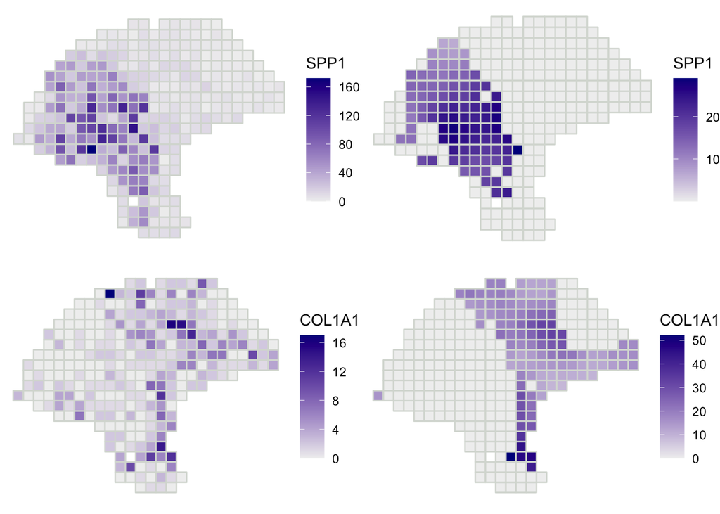

Comparsion of expression patterns.

```r
# Construct sce object for expression visualization
metadata <-  melanoma_st1_adjusted@meta.data
metadata$col <-  melanoma_st1_adjusted@meta.data$col
metadata$row <-  melanoma_st1_adjusted@meta.data$row


sce_adjusted <- SingleCellExperiment(assays = list(counts = melanoma_st1_adjusted@assays$RNA@counts, logcounts = melanoma_st1_adjusted@assays$RNA@data),
                            colData= metadata)

sce_adjusted <- spatialPreprocess(sce_adjusted, platform="ST",
                              n.PCs=4,n.HVGs = 2000, log.normalize=FALSE,skip.PCA=TRUE)

p1 <- featurePlot(
  sce_adjusted,
  "SPP1",
  assay.type = "logcounts",
  diverging = FALSE,
  low = NULL,
  high = "darkblue",
  mid = NULL,
  color = NULL,
  platform = NULL,
  is.enhanced = NULL,
)

p2 <- featurePlot(
  sce_adjusted,
  "COL1A1",
  assay.type = "logcounts",
  diverging = FALSE,
  low = NULL,
  high = "darkblue",
  mid = NULL,
  color = NULL,
  platform = NULL,
  is.enhanced = NULL,
)


sce_ST <- SingleCellExperiment(assays = list(counts = melanoma_st1@assays$RNA@counts, logcounts = melanoma_st1@assays$RNA@data),
                            colData=metadata)

sce_ST <- spatialPreprocess(sce_ST, platform="ST",
                              n.PCs=4,n.HVGs = 2000, log.normalize=FALSE,skip.PCA=TRUE)

p3 <- featurePlot(
  sce_ST,
  "SPP1",
  assay.type = "logcounts",
  diverging = FALSE,
  low = NULL,
  high = "darkblue",
  mid = NULL,
  color = NULL,
  platform = NULL,
  is.enhanced = NULL,
)

p4 <- featurePlot(
  sce_ST,
  "COL1A1",
  assay.type = "logcounts",
  diverging = FALSE,
  low = NULL,
  high = "darkblue",
  mid = NULL,
  color = NULL,
  platform = NULL,
  is.enhanced = NULL,
)

ggarrange(p3, p1, p4, p2, ncol = 2, nrow = 2)
```